# EasyVisa Project

##### **Question 3: Does work experience influence visa status?**

Experienced professionals might look abroad for opportunities to improve their lifestyles and career development.

**Answer**

Yes. Overall, applicants without job experience are approved 56% of the time and denied 43# of the time. However, for applicants with experience, the odds of Certification improve to 74% as compared to only a 26% denial rate.

Below is the breakdown by job experience and % contribution both at the work experience level.

```
Crosstab of case_status by Has Job Experience:
                    Certified  Denied
N                        5994    4684
Y                       11024    3778

Percentage of Case Status by Has Job Experience:
                    Certified     Denied
N                   56.134108  43.865892
Y                   74.476422  25.523578

Overall percentage contribution by category
                    Certified     Denied
N                   23.524333  18.383046
Y                   43.265306  14.827316
```

Supporting Calculations

```python
# Create a crosstab
crosstab_has_job_experience_case_status = pd.crosstab(df['has_job_experience'], df['case_status'])

# Calculate the percentage for each status by has_job_experience
crosstab_has_job_experience_case_status_percentage = crosstab_has_job_experience_case_status.div(crosstab_has_job_experience_case_status.sum(axis=1), axis=0) * 100

# Calculate overall percentage contribution by category
crosstab_overall_percentage_has_job_experience = crosstab_has_job_experience_case_status / crosstab_has_job_experience_case_status.values.sum() * 100

# Display the crosstab
print("Crosstab of case_status by Has Job Experience")
print(crosstab_has_job_experience_case_status)

print("\nPercentage of Case Status by Has Job Experience")
print(crosstab_has_job_experience_case_status_percentage)

# Display the overall percentage contribution
print("\nOverall percentage contribution by category")
print(crosstab_overall_percentage_has_job_experience)
```

```
Crosstab of case_status by Has Job Experience
case_status         Certified  Denied
has_job_experience
N                        5994    4684
Y                       11024    3778

Percentage of Case Status by Has Job Experience
case_status         Certified     Denied
has_job_experience
N                   56.134108  43.865892
Y                   74.476422  25.523578

Overall percentage contribution by category
case_status         Certified     Denied
has_job_experience
N                   23.524333  18.383046
Y                   43.265306  14.827316
```

##### **Question 4: Which pay unit is most likely to be certified for a visa?**

In the United States, employees are paid at different intervals.

**Answer**

Annual salaries vs. short-term salaries are far more prevalent in the number of Certified applications.

- When considering only annual salary applications, applicants are Certified nearly 70% of the time.
- When considering all applications, the value drops slightly to 63% of all Certified visa applications.
- The worst success ratio is for hourly applications, where nearly 2/3 of all applications are Denied.

```
Crosstab of case_status by Unit of Wage:
              Certified  Denied
Hour                747    1410
Month                55      34
Week                169     103
Year              16047    6915

Percentage of Case Status by Unit of Wage:
              Certified     Denied
Hour          34.631433  65.368567
Month         61.797753  38.202247
Week          62.132353  37.867647
Year          69.885027  30.114973

Overall percentage contribution by category:
               Certified     Denied
Hour           2.931711   5.533752
Month          0.215856   0.133438
Week           0.663265   0.404239
Year          62.978807  27.138932
```

Supporting Calculations

```python
# Create a crosstab
crosstab_unit_of_wage_case_status = pd.crosstab(df['unit_of_wage'], df['case_status'])

# Calculate the percentage for each status by unit_of_wage
crosstab_unit_of_wage_case_status_percentage = crosstab_unit_of_wage_case_status.div(crosstab_unit_of_wage_case_status.sum(axis=1), axis=0) * 100

# Calculate overall percentage contribution by category
crosstab_overall_percentage_unit_of_wage = crosstab_unit_of_wage_case_status / crosstab_unit_of_wage_case_status.values.sum() * 100

# Display the crosstab
print("Crosstab of case_status by Unit of Wage")
print(crosstab_unit_of_wage_case_status)

print("\nPercentage of Case Status by Unit of Wage")
print(crosstab_unit_of_wage_case_status_percentage)

# Display the overall percentage contribution
print("\nOverall percentage contribution by category")
print(crosstab_overall_percentage_unit_of_wage)
```

```
Crosstab of case_status by Unit of Wage
case_status   Certified  Denied
unit_of_wage
Hour                747    1410
Month                55      34
Week                169     103
Year              16047    6915

Percentage of Case Status by Unit of Wage
case_status   Certified     Denied
unit_of_wage
Hour          34.631433  65.368567
Month         61.797753  38.202247
Week          62.132353  37.867647
Year          69.885027  30.114973

Overall percentage contribution by category
case_status   Certified     Denied
unit_of_wage
Hour           2.931711   5.533752
Month          0.215856   0.133438
Week           0.663265   0.404239
Year          62.978807  27.138932
```

##### **Question 5: How does the visa status change with the prevailing wage?**

The US government has established a prevailing wage to protect local talent and foreign workers.

**Answer**

Prevailing wages do not seem to vary widely for Certified vs. Denied applicants. This makes sense, since the wages are set by the government irrespective of whether applicants are certified or denied.

- Wage mean for Certified applications: 77,294
- Wage mean for Denied applications: 68,749

That said, we did find a slight correlation level of .08 between case status and prevailing wages. We should investigate this further in our model to see if this feature should be considered.

Supporting Calculations

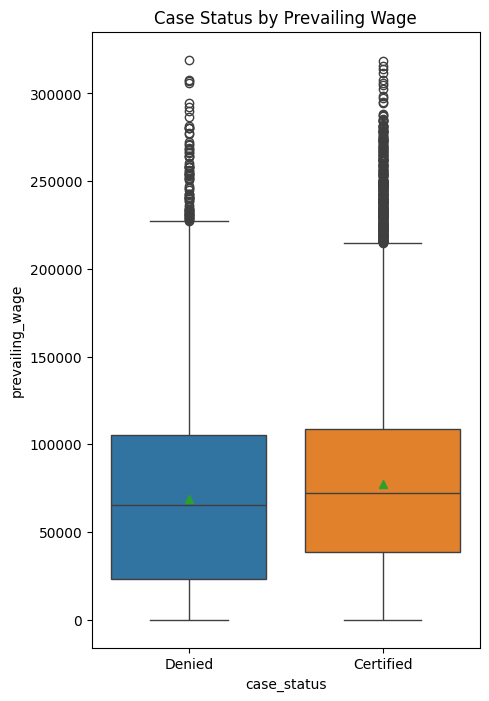

```python
# Re-show boxplot for case status vs. wages
print_categorical_boxplot(df_eda, 'case_status', 'prevailing_wage', 5, 8, 'Case Status by Prevailing Wage')
```

# Building an Ensemble Model

### Model Helpers

Let's import more libraries and define some functions that we will need throughout our modeling process.

```python
# Install - run once
#!pip install nvidia-smi

# Check GPU
gpu_info = !nvidia-smi
gpu_info = '\n'.join(gpu_info)
if gpu_info.find('failed') >= 0:
  print('Not connected to a GPU')
else:
  print(gpu_info)

# Check runtime since we run into RAM issues past this point
from psutil import virtual_memory
ram_gb = virtual_memory().total / 1e9
print('Your runtime has {:.1f} gigabytes of available RAM\n'.format(ram_gb))

if ram_gb < 20:
  print('Not using a high-RAM runtime')
else:
  print('You are using a high-RAM runtime!')
```

```
/bin/bash: line 1: nvidia-smi: command not found
Your runtime has 54.8 gigabytes of available RAM

You are using a high-RAM runtime!
```

```python
# Libraries to build linear model for statistical analysis and prediction
import statsmodels.stats.api as sms
from statsmodels.stats.outliers_influence import variance_inflation_factor

import statsmodels.api as sm
from statsmodels.tools.tools import add_constant

# Libraries to import decision tree classifier and different ensemble classifiers
from sklearn.tree import DecisionTreeClassifier
from sklearn import tree

from xgboost import XGBClassifier

from sklearn.ensemble import (
    BaggingClassifier,
    RandomForestClassifier,
    AdaBoostClassifier,
    GradientBoostingClassifier,
    StackingClassifier
  )

# Library to model, get different metric scores
from sklearn import metrics
from sklearn.metrics import (
    confusion_matrix,
    ConfusionMatrixDisplay,
    classification_report,
    accuracy_score,
    precision_score,
    recall_score,
    f1_score
    #roc_auc_score
    )

# To tune different models
from sklearn.model_selection import GridSearchCV
from sklearn.model_selection import RandomizedSearchCV
```

```python
# Function to compute different metrics to check performance of a classification model built using sklearn
def model_performance_classification_sklearn(model, predictors, target):
    '''
    Function to compute different metrics to check classification model performance

    model: classifier
    predictors: independent variables
    target: dependent variable
    '''

    # predicting using the independent variables
    pred = model.predict(predictors)

    acc = accuracy_score(target, pred)  # to compute Accuracy
    recall = recall_score(target, pred)  # to compute Recall
    precision = precision_score(target, pred)  # to compute Precision
    f1 = f1_score(target, pred)  # to compute F1-score

    # creating a dataframe of metrics
    df_perf = pd.DataFrame(
        {
            'Accuracy': acc,
            'Recall': recall,
            'Precision': precision,
            'F1': f1,
        },
        index=[0],
    )

    return df_perf
```

```python
# Function to plot the confusion matrix and show % contributions - does not work
def confusion_matrix_sklearn(model, predictors, target):
    '''
    To plot the confusion_matrix with percentages

    model: classifier
    predictors: independent variables
    target: dependent variable
    '''
    y_pred = model.predict(predictors)
    cm = confusion_matrix(target, y_pred)
    labels = np.asarray(
        [
            ['{0:0.0f}'.format(item) + '\n{0:.2%}'.format(item / cm.flatten().sum())]
            for item in cm.flatten()
        ]
    ).reshape(2, 2)

    plt.figure(figsize=(6, 4))
    sns.heatmap(cm, annot=labels, fmt='')
    plt.ylabel('True label')
    plt.xlabel('Predicted label')
```

```python
# This function plots a confusion_matrix for a classification model - works

def confusion_matrix_statsmodels(model, predictors, target, threshold=0.5):
    '''
    To plot the confusion_matrix with percentages

    model: classifier
    predictors: independent variables
    target: dependent variable
    threshold: threshold for classifying the observation as class 1
    '''
    y_pred = model.predict(predictors) > threshold
    cm = confusion_matrix(target, y_pred)
    labels = np.asarray(
        [
            ['{0:0.0f}'.format(item) + '\n{0:.2%}'.format(item / cm.flatten().sum())]
            for item in cm.flatten()
        ]
    ).reshape(2, 2)

    plt.figure(figsize=(6, 4))
    sns.heatmap(cm, annot=labels, fmt='')
    plt.ylabel('True label')
    plt.xlabel('Predicted label')
```

### Data Preprocessing

As we start to prepare for modeling, let's reexamine our data and determine what cleanup is needed.

- We already determined no duplicates or missing values exist.
- We know that we want to focus on case status as our primary dependent variable of interest.
- We know that we have a number of Yes/No values that can benefit from integer conversion.Similarly, we have several categorical variables that will likely turn into dummy variables. We made these conversions on our EDA dataset, but not on our actual dataset.

```python
# List our categorical series again, with their unique values
for series in series_values:
    if series in list_catcol:
      print('Feature (Categorical):', series)
      print(df[series].unique())
      print()
```

```
Feature (Categorical): continent
['Asia' 'Africa' 'North America' 'Europe' 'South America' 'Oceania']

Feature (Categorical): education_of_employee
['High School' "Master's" "Bachelor's" 'Doctorate']

Feature (Categorical): has_job_experience
['N' 'Y']

Feature (Categorical): requires_job_training
['N' 'Y']

Feature (Categorical): region_of_employment
['West' 'Northeast' 'South' 'Midwest' 'Island']

Feature (Categorical): unit_of_wage
['Hour' 'Year' 'Week' 'Month']

Feature (Categorical): full_time_position
['Y' 'N']

Feature (Categorical): case_status
['Denied' 'Certified']
```

```python
# List our numerical series, with their unique values
print('Feature (Numerical)',list_numcol)
```

```
Feature (Numerical) ['no_of_employees', 'yr_of_estab', 'prevailing_wage']
```

## Feature Engineering

```python
# Copy the dataframe so we don't taint the original
df_clean = df.copy()
```

```python
# Convert Case Status to an integer status

# Define mapping dictionary
mapping_case_status = {
    'Denied': 0,
    'Certified': 1
    }

# Remap values
remapped_case_status = [mapping_case_status[value] for value in series_values['case_status']]

print('Remapped values for case status:', remapped_case_status)

# Update the column
df_clean['case_status_int'] = df_clean['case_status'].map(mapping_case_status).astype(int)

# Drop the original column
df_clean.drop('case_status', axis=1, inplace=True)
```

```
Remapped values for case status: [0, 1]
```

```python
# Drop the case ID column
df_clean.drop('case_id', axis=1, inplace=True)
```

```python
# Check series datatypes again
df_clean.dtypes
```

|  | 0 |
| --- | --- |
| continent | object |
| education_of_employee | object |
| has_job_experience | object |
| requires_job_training | object |
| no_of_employees | int64 |
| yr_of_estab | int64 |
| region_of_employment | object |
| prevailing_wage | float64 |
| unit_of_wage | object |
| full_time_position | object |
| case_status_int | int64 |

**dtype:** object

## Create Training and Test Datasets

```python
# Split data into test and training sets

# Define independent  and dependent variables
# Target variable: Case Status
X = df_clean.drop(['case_status_int'], axis=1)
y = df_clean['case_status_int']

# adding a constant to the independent variables
X = sm.add_constant(X)

# creating dummy variables
X = pd.get_dummies(X, drop_first=True)

# Convert  attributes into float type for modeling
X = X.astype(float)
y = y.astype(float)

# splitting data in train and test sets
X_train, X_test, y_train, y_test = train_test_split(
    X, y, test_size=0.3, random_state=1, stratify=y)
```

```python
# Check sizes
print('X_train, X_test counts',X_train.shape, X_test.shape)
print('y_train, y_test counts',y_train.shape, y_test.shape)
```

```
X_train, X_test counts (17836, 22) (7644, 22)
y_train, y_test counts (17836,) (7644,)
```

```python
# Finally, create our new numerical and categorical column lists
list_catcol = df_clean.select_dtypes(include=['object']).columns.to_list()
list_numcol = df_clean.select_dtypes(exclude=['object']).columns.to_list()

print('Catcol:',list_catcol)
print('Numcol:',list_numcol)
```

```
Catcol: ['continent', 'education_of_employee', 'has_job_experience', 'requires_job_training', 'region_of_employment', 'unit_of_wage', 'full_time_position']
Numcol: ['no_of_employees', 'yr_of_estab', 'prevailing_wage', 'case_status_int']
```

```python
# Preview again
df_clean
```

|  | continent | education_of_employee | has_job_experience | requires_job_training | no_of_employees | yr_of_estab | region_of_employment | prevailing_wage | unit_of_wage | full_time_position | case_status_int |
| --- | --- | --- | --- | --- | --- | --- | --- | --- | --- | --- | --- |
| 0 | Asia | High School | N | N | 14513 | 2007 | West | 592.2029 | Hour | Y | 0 |
| 1 | Asia | Master's | Y | N | 2412 | 2002 | Northeast | 83425.6500 | Year | Y | 1 |
| 2 | Asia | Bachelor's | N | Y | 44444 | 2008 | West | 122996.8600 | Year | Y | 0 |
| 3 | Asia | Bachelor's | N | N | 98 | 1897 | West | 83434.0300 | Year | Y | 0 |
| 4 | Africa | Master's | Y | N | 1082 | 2005 | South | 149907.3900 | Year | Y | 1 |
| ... | ... | ... | ... | ... | ... | ... | ... | ... | ... | ... | ... |
| 25475 | Asia | Bachelor's | Y | Y | 2601 | 2008 | South | 77092.5700 | Year | Y | 1 |
| 25476 | Asia | High School | Y | N | 3274 | 2006 | Northeast | 279174.7900 | Year | Y | 1 |
| 25477 | Asia | Master's | Y | N | 1121 | 1910 | South | 146298.8500 | Year | N | 1 |
| 25478 | Asia | Master's | Y | Y | 1918 | 1887 | West | 86154.7700 | Year | Y | 1 |
| 25479 | Asia | Bachelor's | Y | N | 3195 | 1960 | Midwest | 70876.9100 | Year | Y | 1 |

25480 rows × 11 columns

## Exploratory Data Re-analysis (EDA Round 2)

- We will recheck for nulls and outliers before we start the model.

##### Null check

```python
print('The dataset has',df_clean.isnull().sum(),'null values.')
```

```
The dataset has continent                0
education_of_employee    0
has_job_experience       0
requires_job_training    0
no_of_employees          0
yr_of_estab              0
region_of_employment     0
prevailing_wage          0
unit_of_wage             0
full_time_position       0
case_status_int          0
dtype: int64 null values.
```

#### Outlier check

Earlier, we noted some negative values for employee counts. Given that we have a very large dataset and it's only 33 rows, let's drop those for this analysis since we cannot confirm if the error is simply a negative sign, or a bad data entry altogether.

```python
df_clean = df_clean[df_clean['no_of_employees'] >= 0]
```

#### Re-run Distribution

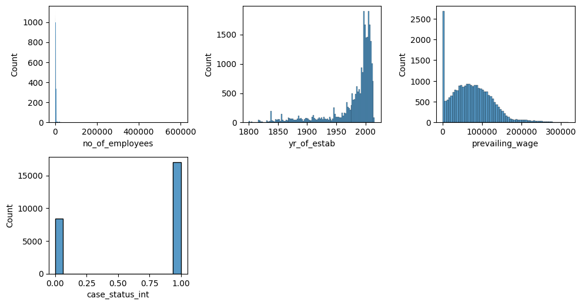

```python
# Plot as histograms
plt.figure(figsize=(10, 10))

for i, col in enumerate(list_numcol):
  plt.subplot(4, 3, i + 1)
  sns.histplot(data=df_clean, x=col)
  plt.tight_layout()

plt.show()
```

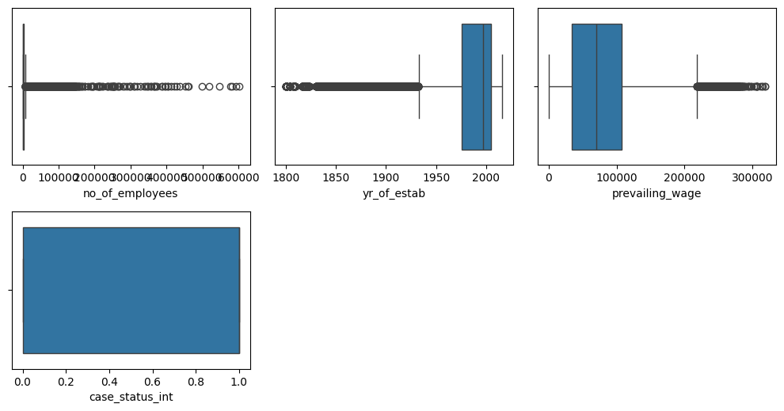

```python
# Show as boxplots
plt.figure(figsize=(10, 10))

for i, col in enumerate(list_numcol):
  plt.subplot(4, 3, i + 1)
  sns.boxplot(data=df_clean, x=col)
  plt.tight_layout()

plt.show()
```

## Model Construction

For the business case in this project, we know that our goal is to accurately predict Certified visa approvals by determining which, if any, features influence the possibility of a visa application being Certified or Denied.

**Hypotheses**

Null Hypothesis:

- H<sub>0</sub>: No features have an impact on case status outcomes.

Alternative Hypothesis:

- H<sub>A</sub>: One or more features have an impact on case status outcomes.

**Model Metric**

- If the model incorrectly predicts a visa will be Certified, but it is actually Denied, we have a False Positive. The number of actual Certifications will be overstated, and visa spots may potentially be left empty if quotas exist.
- If the model incorrectly predicts a visa will be Denied, but it is actually Certified, we have a False Negative. The number of Certifications will be higher than expected, and some people who were Certified may not have employment opportunities.

Since we want to accurately predict both scenarios, we should seek to optimize both Recall and Precision, and use the F1 Score to assess model performance. This will provide the best balance to avoid over or under-certifying applicants.

The remainder of this notebook defines diverse model types. We will construct six different types of models, assess the performance of each, tune its hyperparameters, and then evaluate all tuned models to choose our final model set.

Model Types

- Decision Tree
- Gradient Boost
- AdaBoost
- Bagging
- Random Forest
- XGBoost

### Individual Models

#### Decision Tree (Classification)

First, we will build a decision tree model using the default parameters.

Base parameters for Decision Tree

```
param_grid = {
    'max_depth': np.arange(2,6),
    'min_samples_leaf': [1, 4, 7],
    'max_leaf_nodes' : [10, 15],
    'min_impurity_decrease': [0.0001,0.001]
}
```

```python
model_decision_tree = DecisionTreeClassifier(
      criterion='gini',
      random_state=1,
      class_weight='balanced'
      )
```

```python
model_decision_tree.fit(X_train, y_train)
```

```
DecisionTreeClassifier(class_weight='balanced', random_state=1)
```

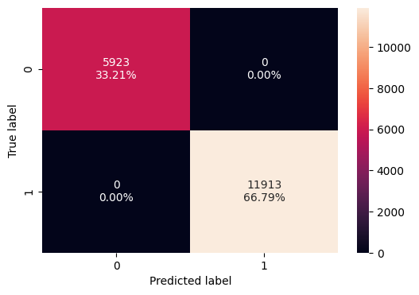

```python
confusion_matrix_sklearn(model_decision_tree, X_train, y_train)
```

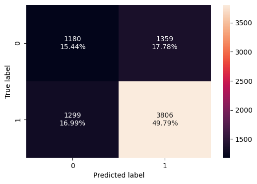

```python
confusion_matrix_sklearn(model_decision_tree, X_test, y_test)
```

```python
model_decision_tree_train_perf = model_performance_classification_sklearn(model_decision_tree, X_train, y_train)
print('Training performance \n',model_decision_tree_train_perf)
```

```
Training performance
    Accuracy  Recall  Precision   F1
0       1.0     1.0        1.0  1.0
```

```python
model_decision_tree_test_perf = model_performance_classification_sklearn(model_decision_tree, X_test, y_test)
print('Testing performance \n',model_decision_tree_test_perf)
```

```
Testing performance
    Accuracy    Recall  Precision        F1
0  0.652276  0.745544   0.736883  0.741188
```

**OBSERVATION**

The original decision tree model was overfitted, since the training data performed perfectly, but the test data yielded much lower F1 score values. Each of the confusion matrix quadrants also had a high standard error rate in double digits.

After tuning, the training and test models performed more consistently, even though the overall F1 did not increase by much.

#### Random Forest (Classification)

Base parameters for Random Forest:

```
param_grid = {
    "n_estimators": [50,110,25],
    "min_samples_leaf": np.arange(1, 4),
    "max_features": [np.arange(0.3, 0.6, 0.1),'sqrt'],
    "max_samples": np.arange(0.4, 0.7, 0.1)
}
```

```python
model_random_forest = RandomForestClassifier(random_state=1)
model_random_forest.fit(X_train,y_train)
```

```
RandomForestClassifier(random_state=1)
```

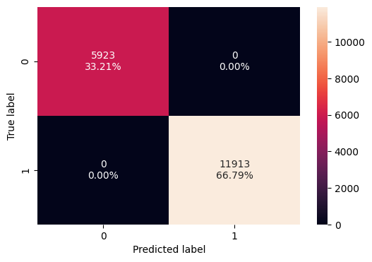

```python
confusion_matrix_sklearn(model_random_forest,X_train,y_train)
```

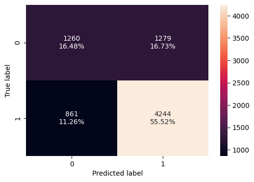

```python
confusion_matrix_sklearn(model_random_forest,X_test,y_test)
```

```python
model_random_forest_train_perf = model_performance_classification_sklearn(model_random_forest,X_train,y_train)
print('Training performance \n',model_random_forest_train_perf)
```

```
Training performance
    Accuracy  Recall  Precision   F1
0       1.0     1.0        1.0  1.0
```

```python
model_random_forest_test_perf = model_performance_classification_sklearn(model_random_forest,X_test,y_test)
print('Test performance \n',model_random_forest_test_perf)
```

```
Test performance
    Accuracy    Recall  Precision        F1
0  0.720042  0.831342   0.768423  0.798645
```

#### Gradient Boost (Boosting)

Base parameters for Gradient Boosting:

```
param_grid = {
    "init": [AdaBoostClassifier(random_state=1),DecisionTreeClassifier(random_state=1)],
    "n_estimators": np.arange(50,110,25),
    "learning_rate": [0.01,0.1,0.05],
    "subsample":[0.7,0.9],
    "max_features":[0.5,0.7,1],
}
```

```python
model_gradient_boost = GradientBoostingClassifier(random_state=1)
model_gradient_boost.fit(X_train,y_train)
```

```
GradientBoostingClassifier(random_state=1)
```

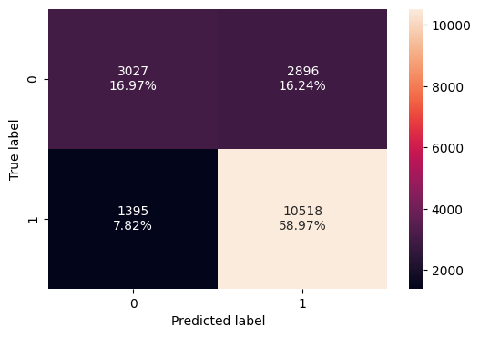

```python
confusion_matrix_sklearn(model_gradient_boost, X_train,y_train)
```

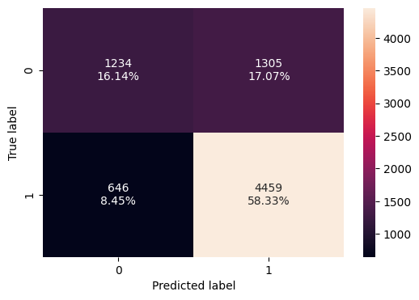

```python
confusion_matrix_sklearn(model_gradient_boost, X_test,y_test)
```

```python
model_gradient_boost_train_perf = model_performance_classification_sklearn(model_gradient_boost,X_train,y_train)
print("Training performance \n",model_gradient_boost_train_perf)
```

```
Training performance
    Accuracy    Recall  Precision        F1
0  0.759419  0.882901   0.784106  0.830576
```

```python
model_gradient_boost_test_perf = model_performance_classification_sklearn(model_gradient_boost,X_test,y_test)
print("Training performance \n",model_gradient_boost_test_perf)
```

```
Training performance
    Accuracy    Recall  Precision        F1
0  0.744767  0.873457   0.773595  0.820499
```

#### AdaBoost (Boosting)

Base parameters for Adaboost:

```
param_grid = {
    "n_estimators": np.arange(50,110,25),
    "learning_rate": [0.01,0.1,0.05],
    "base_estimator": [
        DecisionTreeClassifier(max_depth=2, random_state=1),
        DecisionTreeClassifier(max_depth=3, random_state=1),
    ],
}
```

```python
model_adaboost = AdaBoostClassifier(random_state=1)
model_adaboost.fit(X_train,y_train)
```

```
AdaBoostClassifier(random_state=1)
```

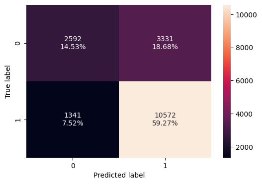

```python
confusion_matrix_sklearn(model_adaboost, X_train,y_train)
```

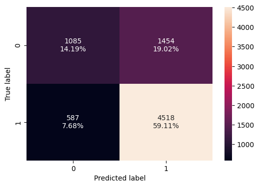

```python
confusion_matrix_sklearn(model_adaboost, X_test,y_test)
```

```python
model_adaboost_train_perf = model_performance_classification_sklearn(model_adaboost,X_train,y_train)
print('Training performance \n',model_adaboost_train_perf)
```

```
Training performance
    Accuracy    Recall  Precision        F1
0  0.738058  0.887434   0.760411  0.819027
```

```python
model_adaboost_test_perf = model_performance_classification_sklearn(model_adaboost,X_test,y_test)
print('Testing performance \n',model_adaboost_test_perf)
```

```
Testing performance
    Accuracy    Recall  Precision        F1
0  0.732993  0.885015    0.75653  0.815744
```

#### XGBoost (Boosting)

Base parameters for XGBoost:

```
param_grid={'n_estimators':np.arange(50,110,25),
            'scale_pos_weight':[1,2,5],
            'learning_rate':[0.01,0.1,0.05],
            'gamma':[1,3],
            'subsample':[0.7,0.9]
}
```

```python
model_xgboost = XGBClassifier(random_state=1,eval_metric='logloss')
model_xgboost.fit(X_train,y_train)
```

```
XGBClassifier(base_score=None, booster=None, callbacks=None,
              colsample_bylevel=None, colsample_bynode=None,
              colsample_bytree=None, device=None, early_stopping_rounds=None,
              enable_categorical=False, eval_metric='logloss',
              feature_types=None, gamma=None, grow_policy=None,
              importance_type=None, interaction_constraints=None,
              learning_rate=None, max_bin=None, max_cat_threshold=None,
              max_cat_to_onehot=None, max_delta_step=None, max_depth=None,
              max_leaves=None, min_child_weight=None, missing=nan,
              monotone_constraints=None, multi_strategy=None, n_estimators=None,
              n_jobs=None, num_parallel_tree=None, random_state=1, ...)
```

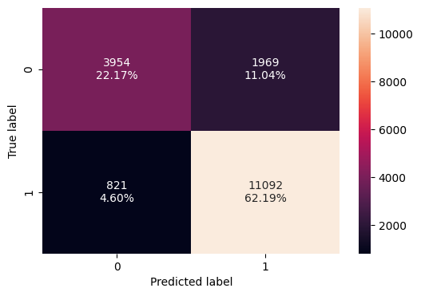

```python
confusion_matrix_sklearn(model_xgboost, X_train,y_train)
```

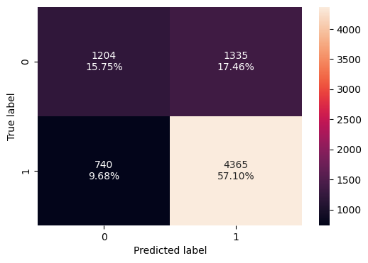

```python
confusion_matrix_sklearn(model_xgboost, X_test,y_test)
```

```python
model_xgboost_train_perf = model_performance_classification_sklearn(model_xgboost,X_train,y_train)
print('Training performance \n',model_xgboost_train_perf)
```

```
Training performance
    Accuracy    Recall  Precision        F1
0  0.843575  0.931084   0.849246  0.888284
```

```python
model_xgboost_test_perf = model_performance_classification_sklearn(model_xgboost,X_test,y_test)
print('Test performance \n',model_xgboost_test_perf)
```

```
Test performance
    Accuracy    Recall  Precision        F1
0  0.728545  0.855044   0.765789  0.807959
```

#### Bagging

Base parameters for Bagging Classifier:

```
param_grid = {
    'max_samples': [0.8,0.9,1],
    'max_features': [0.7,0.8,0.9],
    'n_estimators' : [30,50,70],
}
```

### Summary: Untuned Models

```python
model_bagging = BaggingClassifier(random_state=1)
model_bagging.fit(X_train,y_train)
```

```
BaggingClassifier(random_state=1)
```

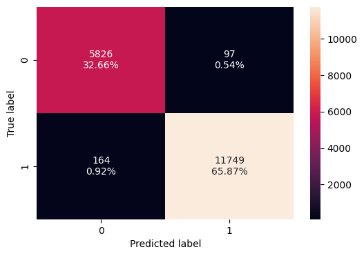

```python
confusion_matrix_sklearn(model_bagging, X_train, y_train)
```

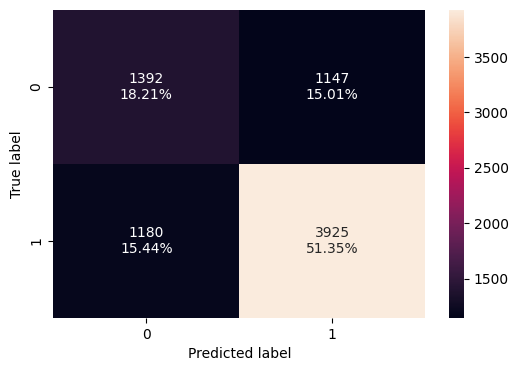

```python
confusion_matrix_sklearn(model_bagging, X_test, y_test)
```

```python
model_bagging_train_perf = model_performance_classification_sklearn(model_bagging, X_train, y_train)
print('Training performance \n',model_bagging_train_perf)
```

```
Training performance
    Accuracy    Recall  Precision        F1
0  0.985367  0.986234   0.991812  0.989015
```

```python
model_bagging_test_perf = model_performance_classification_sklearn(model_bagging, X_test, y_test)
print('Testing performance \n',model_bagging_test_perf)
```

```
Testing performance
    Accuracy    Recall  Precision        F1
0  0.695578  0.768854   0.773856  0.771347
```

## Model Tuning

Now that we have our base model performance, let's try to tune the models to identify proper settings and feature performance.

When tuning these models, since we are emphasizing F1 scoring, we will specify that as our scoring metric.

### Hypertuning: Decision Tree (Classification)

```python
#Tuning the decision tree

# Build estimator - original
estimator_decision_tree = DecisionTreeClassifier(class_weight='balanced' ,random_state=1)

# Grid of recommended tuning parameters,
parameter_grid_dt = {
    'max_depth': np.arange(2,6),
    'min_samples_leaf': [1, 4, 7],
    'max_leaf_nodes' : [10, 15],
    'min_impurity_decrease': [0.0001,0.001]
    }

# Type of scoring used to compare parameter combinations - we care most about f1
scorer_dt = metrics.make_scorer(metrics.f1_score)

# Run the grid search
grid_obj_decision_tree = GridSearchCV(
      estimator_decision_tree,
      parameter_grid_dt,
      scoring=scorer_dt
      )

# Fit the model to the data
grid_obj_decision_tree = grid_obj_decision_tree.fit(X_train, y_train)

# Set the model to the best estimator parameters
tuned_model_decision_tree = grid_obj_decision_tree.best_estimator_

# Fit the tuned model to the data with best estimator
tuned_model_decision_tree.fit(X_train, y_train)
```

```
DecisionTreeClassifier(class_weight='balanced', max_depth=5, max_leaf_nodes=10,
                       min_impurity_decrease=0.0001, random_state=1)
```

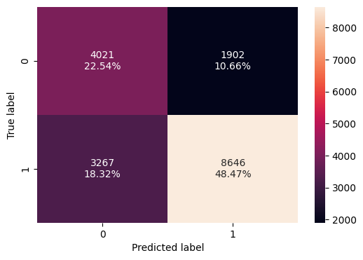

```python
confusion_matrix_sklearn(tuned_model_decision_tree, X_train, y_train)
```

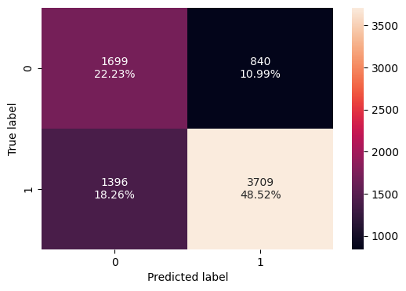

```python
confusion_matrix_sklearn(tuned_model_decision_tree, X_test, y_test)
```

```python
tuned_model_decision_tree_train_perf = model_performance_classification_sklearn(tuned_model_decision_tree, X_train, y_train)
print('Training performance \n',model_decision_tree_train_perf)
```

[output not shown]

```python
tuned_model_decision_tree_test_perf = model_performance_classification_sklearn(tuned_model_decision_tree, X_test, y_test)
print('Training performance \n',tuned_model_decision_tree_test_perf)
```

```
Training performance
    Accuracy    Recall  Precision        F1
0  0.707483  0.726543   0.815344  0.768386
```

```python
# Check feature importance - Decision Tree - Percents
display(pd.DataFrame(tuned_model_decision_tree.feature_importances_
                     , columns = ['Imp']
                     , index = X_train.columns).sort_values(by = 'Imp', ascending = False))
```

|  | Imp |
| --- | --- |
| education_of_employee_High School | 0.345166 |
| has_job_experience_Y | 0.242389 |
| prevailing_wage | 0.130680 |
| education_of_employee_Master's | 0.096143 |
| continent_Europe | 0.071044 |
| education_of_employee_Doctorate | 0.070558 |
| region_of_employment_Midwest | 0.044020 |
| unit_of_wage_Year | 0.000000 |
| unit_of_wage_Week | 0.000000 |
| unit_of_wage_Month | 0.000000 |
| region_of_employment_West | 0.000000 |
| region_of_employment_South | 0.000000 |
| region_of_employment_Northeast | 0.000000 |
| const | 0.000000 |
| requires_job_training_Y | 0.000000 |
| no_of_employees | 0.000000 |
| continent_South America | 0.000000 |
| continent_Oceania | 0.000000 |
| continent_North America | 0.000000 |
| continent_Asia | 0.000000 |
| yr_of_estab | 0.000000 |
| full_time_position_Y | 0.000000 |

```python
# Define feature names (first time only)
feature_names = X_train.columns
```

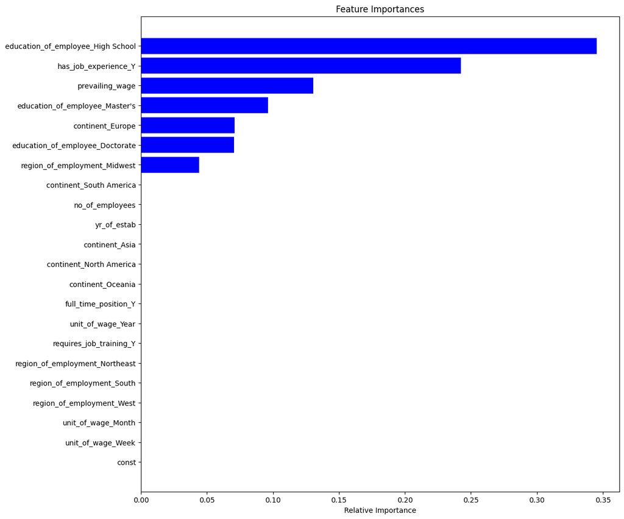

```python
# Check feature importance - Decision Tree - Visualization
importances_dt = tuned_model_decision_tree.feature_importances_
indices_dt = np.argsort(importances_dt)

plt.figure(figsize=(12,12))
plt.title('Feature Importances')
plt.barh(range(len(indices_dt)), importances_dt[indices_dt], color='blue', align='center')
plt.yticks(range(len(indices_dt)), [feature_names[i] for i in indices_dt])
plt.xlabel('Relative Importance')
plt.show()
```